# Risk Factor Analysis

## Outcome Variable

**Outcome Variable:** wast_rec90d

## Predictor Variables

**Intervention Variable:** cleanck

**Adjustment Set:**

unadjusted

## Stratifying Variables

The analysis was stratified on these variable(s):

- agecat
- studyid
- country

## Data Summary

| agecat | studyid | country | cleanck | wast_rec90d | n_cell | n | outcome_variable |
| --- | --- | --- | --- | --- | --- | --- | --- |
| 0-24 months | ki0047075b-MAL-ED | SOUTH AFRICA | 1 | 0 | 0 | 1 | wast_rec90d |
| 0-24 months | ki0047075b-MAL-ED | SOUTH AFRICA | 1 | 1 | 1 | 1 | wast_rec90d |
| 0-24 months | ki0047075b-MAL-ED | SOUTH AFRICA | 0 | 0 | 0 | 1 | wast_rec90d |
| 0-24 months | ki0047075b-MAL-ED | SOUTH AFRICA | 0 | 1 | 0 | 1 | wast_rec90d |
| 0-24 months | ki1000108-CMC-V-BCS-2002 | INDIA | 1 | 0 | 38 | 324 | wast_rec90d |
| 0-24 months | ki1000108-CMC-V-BCS-2002 | INDIA | 1 | 1 | 80 | 324 | wast_rec90d |
| 0-24 months | ki1000108-CMC-V-BCS-2002 | INDIA | 0 | 0 | 82 | 324 | wast_rec90d |
| 0-24 months | ki1000108-CMC-V-BCS-2002 | INDIA | 0 | 1 | 124 | 324 | wast_rec90d |
| 0-24 months | ki1000108-IRC | INDIA | 1 | 0 | 84 | 383 | wast_rec90d |
| 0-24 months | ki1000108-IRC | INDIA | 1 | 1 | 135 | 383 | wast_rec90d |
| 0-24 months | ki1000108-IRC | INDIA | 0 | 0 | 72 | 383 | wast_rec90d |
| 0-24 months | ki1000108-IRC | INDIA | 0 | 1 | 92 | 383 | wast_rec90d |
| 0-24 months | ki1017093b-PROVIDE | BANGLADESH | 1 | 0 | 91 | 308 | wast_rec90d |
| 0-24 months | ki1017093b-PROVIDE | BANGLADESH | 1 | 1 | 144 | 308 | wast_rec90d |
| 0-24 months | ki1017093b-PROVIDE | BANGLADESH | 0 | 0 | 38 | 308 | wast_rec90d |
| 0-24 months | ki1017093b-PROVIDE | BANGLADESH | 0 | 1 | 35 | 308 | wast_rec90d |
| 0-24 months | ki1017093c-NIH-Crypto | BANGLADESH | 1 | 0 | 44 | 215 | wast_rec90d |
| 0-24 months | ki1017093c-NIH-Crypto | BANGLADESH | 1 | 1 | 68 | 215 | wast_rec90d |
| 0-24 months | ki1017093c-NIH-Crypto | BANGLADESH | 0 | 0 | 37 | 215 | wast_rec90d |
| 0-24 months | ki1017093c-NIH-Crypto | BANGLADESH | 0 | 1 | 66 | 215 | wast_rec90d |
| 0-24 months | ki1113344-GMS-Nepal | NEPAL | 1 | 0 | 6 | 583 | wast_rec90d |
| 0-24 months | ki1113344-GMS-Nepal | NEPAL | 1 | 1 | 3 | 583 | wast_rec90d |
| 0-24 months | ki1113344-GMS-Nepal | NEPAL | 0 | 0 | 259 | 583 | wast_rec90d |
| 0-24 months | ki1113344-GMS-Nepal | NEPAL | 0 | 1 | 315 | 583 | wast_rec90d |
| 0-6 months | ki0047075b-MAL-ED | SOUTH AFRICA | 1 | 0 | 0 | 1 | wast_rec90d |
| 0-6 months | ki0047075b-MAL-ED | SOUTH AFRICA | 1 | 1 | 1 | 1 | wast_rec90d |
| 0-6 months | ki0047075b-MAL-ED | SOUTH AFRICA | 0 | 0 | 0 | 1 | wast_rec90d |
| 0-6 months | ki0047075b-MAL-ED | SOUTH AFRICA | 0 | 1 | 0 | 1 | wast_rec90d |
| 0-6 months | ki1000108-CMC-V-BCS-2002 | INDIA | 1 | 0 | 21 | 201 | wast_rec90d |
| 0-6 months | ki1000108-CMC-V-BCS-2002 | INDIA | 1 | 1 | 57 | 201 | wast_rec90d |
| 0-6 months | ki1000108-CMC-V-BCS-2002 | INDIA | 0 | 0 | 45 | 201 | wast_rec90d |
| 0-6 months | ki1000108-CMC-V-BCS-2002 | INDIA | 0 | 1 | 78 | 201 | wast_rec90d |
| 0-6 months | ki1000108-IRC | INDIA | 1 | 0 | 52 | 232 | wast_rec90d |
| 0-6 months | ki1000108-IRC | INDIA | 1 | 1 | 82 | 232 | wast_rec90d |
| 0-6 months | ki1000108-IRC | INDIA | 0 | 0 | 33 | 232 | wast_rec90d |
| 0-6 months | ki1000108-IRC | INDIA | 0 | 1 | 65 | 232 | wast_rec90d |
| 0-6 months | ki1017093b-PROVIDE | BANGLADESH | 1 | 0 | 27 | 185 | wast_rec90d |
| 0-6 months | ki1017093b-PROVIDE | BANGLADESH | 1 | 1 | 117 | 185 | wast_rec90d |
| 0-6 months | ki1017093b-PROVIDE | BANGLADESH | 0 | 0 | 13 | 185 | wast_rec90d |
| 0-6 months | ki1017093b-PROVIDE | BANGLADESH | 0 | 1 | 28 | 185 | wast_rec90d |
| 0-6 months | ki1017093c-NIH-Crypto | BANGLADESH | 1 | 0 | 8 | 138 | wast_rec90d |
| 0-6 months | ki1017093c-NIH-Crypto | BANGLADESH | 1 | 1 | 60 | 138 | wast_rec90d |
| 0-6 months | ki1017093c-NIH-Crypto | BANGLADESH | 0 | 0 | 5 | 138 | wast_rec90d |
| 0-6 months | ki1017093c-NIH-Crypto | BANGLADESH | 0 | 1 | 65 | 138 | wast_rec90d |
| 0-6 months | ki1113344-GMS-Nepal | NEPAL | 1 | 0 | 4 | 238 | wast_rec90d |
| 0-6 months | ki1113344-GMS-Nepal | NEPAL | 1 | 1 | 2 | 238 | wast_rec90d |
| 0-6 months | ki1113344-GMS-Nepal | NEPAL | 0 | 0 | 90 | 238 | wast_rec90d |
| 0-6 months | ki1113344-GMS-Nepal | NEPAL | 0 | 1 | 142 | 238 | wast_rec90d |
| 6-24 months | ki1000108-CMC-V-BCS-2002 | INDIA | 1 | 0 | 17 | 123 | wast_rec90d |
| 6-24 months | ki1000108-CMC-V-BCS-2002 | INDIA | 1 | 1 | 23 | 123 | wast_rec90d |
| 6-24 months | ki1000108-CMC-V-BCS-2002 | INDIA | 0 | 0 | 37 | 123 | wast_rec90d |
| 6-24 months | ki1000108-CMC-V-BCS-2002 | INDIA | 0 | 1 | 46 | 123 | wast_rec90d |
| 6-24 months | ki1000108-IRC | INDIA | 1 | 0 | 32 | 151 | wast_rec90d |
| 6-24 months | ki1000108-IRC | INDIA | 1 | 1 | 53 | 151 | wast_rec90d |
| 6-24 months | ki1000108-IRC | INDIA | 0 | 0 | 39 | 151 | wast_rec90d |
| 6-24 months | ki1000108-IRC | INDIA | 0 | 1 | 27 | 151 | wast_rec90d |
| 6-24 months | ki1017093b-PROVIDE | BANGLADESH | 1 | 0 | 64 | 123 | wast_rec90d |
| 6-24 months | ki1017093b-PROVIDE | BANGLADESH | 1 | 1 | 27 | 123 | wast_rec90d |
| 6-24 months | ki1017093b-PROVIDE | BANGLADESH | 0 | 0 | 25 | 123 | wast_rec90d |
| 6-24 months | ki1017093b-PROVIDE | BANGLADESH | 0 | 1 | 7 | 123 | wast_rec90d |
| 6-24 months | ki1017093c-NIH-Crypto | BANGLADESH | 1 | 0 | 36 | 77 | wast_rec90d |
| 6-24 months | ki1017093c-NIH-Crypto | BANGLADESH | 1 | 1 | 8 | 77 | wast_rec90d |
| 6-24 months | ki1017093c-NIH-Crypto | BANGLADESH | 0 | 0 | 32 | 77 | wast_rec90d |
| 6-24 months | ki1017093c-NIH-Crypto | BANGLADESH | 0 | 1 | 1 | 77 | wast_rec90d |
| 6-24 months | ki1113344-GMS-Nepal | NEPAL | 1 | 0 | 2 | 345 | wast_rec90d |
| 6-24 months | ki1113344-GMS-Nepal | NEPAL | 1 | 1 | 1 | 345 | wast_rec90d |
| 6-24 months | ki1113344-GMS-Nepal | NEPAL | 0 | 0 | 169 | 345 | wast_rec90d |
| 6-24 months | ki1113344-GMS-Nepal | NEPAL | 0 | 1 | 173 | 345 | wast_rec90d |

The following strata were considered:

- agecat: 0-24 months, studyid: ki0047075b-MAL-ED, country: SOUTH AFRICA
- agecat: 0-24 months, studyid: ki1000108-CMC-V-BCS-2002, country: INDIA
- agecat: 0-24 months, studyid: ki1000108-IRC, country: INDIA
- agecat: 0-24 months, studyid: ki1017093b-PROVIDE, country: BANGLADESH
- agecat: 0-24 months, studyid: ki1017093c-NIH-Crypto, country: BANGLADESH
- agecat: 0-24 months, studyid: ki1113344-GMS-Nepal, country: NEPAL
- agecat: 0-6 months, studyid: ki0047075b-MAL-ED, country: SOUTH AFRICA
- agecat: 0-6 months, studyid: ki1000108-CMC-V-BCS-2002, country: INDIA
- agecat: 0-6 months, studyid: ki1000108-IRC, country: INDIA
- agecat: 0-6 months, studyid: ki1017093b-PROVIDE, country: BANGLADESH
- agecat: 0-6 months, studyid: ki1017093c-NIH-Crypto, country: BANGLADESH
- agecat: 0-6 months, studyid: ki1113344-GMS-Nepal, country: NEPAL
- agecat: 6-24 months, studyid: ki1000108-CMC-V-BCS-2002, country: INDIA
- agecat: 6-24 months, studyid: ki1000108-IRC, country: INDIA
- agecat: 6-24 months, studyid: ki1017093b-PROVIDE, country: BANGLADESH
- agecat: 6-24 months, studyid: ki1017093c-NIH-Crypto, country: BANGLADESH
- agecat: 6-24 months, studyid: ki1113344-GMS-Nepal, country: NEPAL

### Dropped Strata

Some strata were dropped due to rare outcomes:

- agecat: 0-24 months, studyid: ki0047075b-MAL-ED, country: SOUTH AFRICA
- agecat: 0-24 months, studyid: ki1113344-GMS-Nepal, country: NEPAL
- agecat: 0-6 months, studyid: ki0047075b-MAL-ED, country: SOUTH AFRICA
- agecat: 0-6 months, studyid: ki1113344-GMS-Nepal, country: NEPAL
- agecat: 6-24 months, studyid: ki1017093c-NIH-Crypto, country: BANGLADESH
- agecat: 6-24 months, studyid: ki1113344-GMS-Nepal, country: NEPAL

## Methods Detail

We’re interested in the causal parameters $E[Y_a]$ for all values of $a \in \mathcal{A}$. These parameters represent the mean outcome if, possibly contrary to fact, we intervened to set all units to have $A=a$. Under the randomization and positivity assumptions, these are identified by the statistical parameters $\psi_a=E_W[E_{Y|A,W}(Y|A=a,W)]$. In addition, we’re interested in the mean of $Y$, $E[Y]$ under no intervention (the observed mean). We will estimate these parameters by using SuperLearner to fit the relevant likelihood factors – $E_{Y|A,W}(Y|A=a,W)$ and $p(A=a|W)$, and then updating our likelihood fit using a joint TMLE.

For unadjusted analyses ($W=\{\}$), initial likelihoods were estimated using Lrnr_glm to estimate the simple $E(Y|A)$ and Lrnr_mean to estimate $p(A)$. For adjusted analyses, a small library containing Lrnr_glmnet, Lrnr_xgboost, and Lrnr_mean was used.

Having estimated these parameters, we will then use the delta method to estimate relative risks and attributable risks relative to a prespecified baseline level of $A$.

# Results Detail

## Results Plots

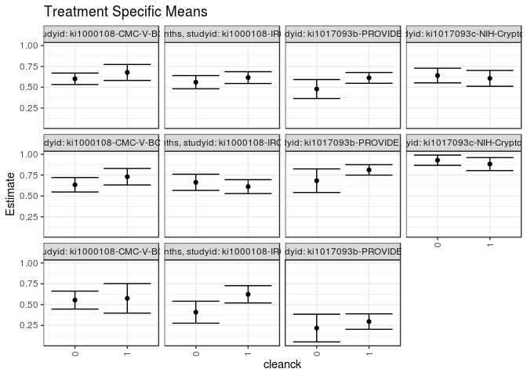

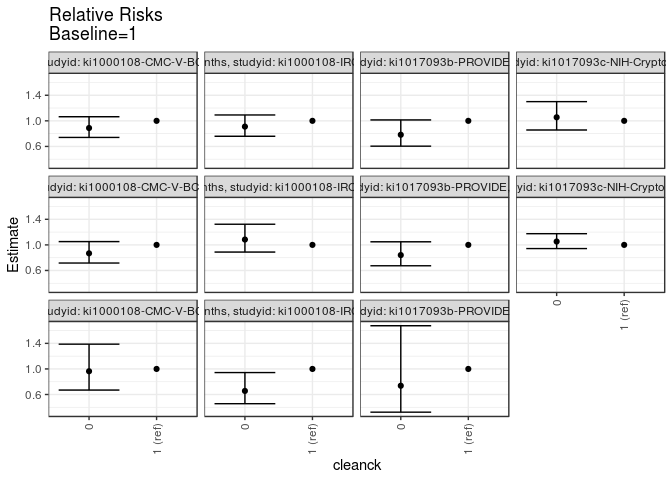

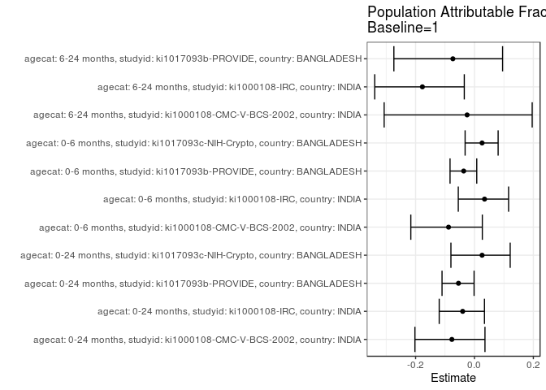

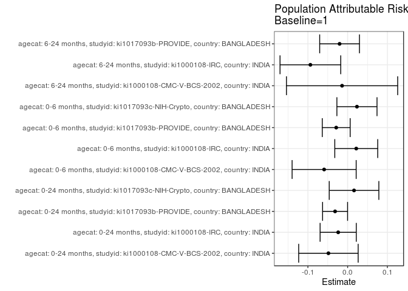

## Results Table

### Parameter: TSM

| agecat | studyid | country | intervention_level | baseline_level | estimate | ci_lower | ci_upper |
| --- | --- | --- | --- | --- | --- | --- | --- |
| 0-24 months | ki1000108-CMC-V-BCS-2002 | INDIA | 1 | NA | 0.6779661 | 0.5823161 | 0.7736161 |
| 0-24 months | ki1000108-CMC-V-BCS-2002 | INDIA | 0 | NA | 0.6019417 | 0.5333539 | 0.6705295 |
| 0-24 months | ki1000108-IRC | INDIA | 1 | NA | 0.6164384 | 0.5458049 | 0.6870719 |
| 0-24 months | ki1000108-IRC | INDIA | 0 | NA | 0.5609756 | 0.4816525 | 0.6402987 |
| 0-24 months | ki1017093b-PROVIDE | BANGLADESH | 1 | NA | 0.6127660 | 0.5481876 | 0.6773443 |
| 0-24 months | ki1017093b-PROVIDE | BANGLADESH | 0 | NA | 0.4794521 | 0.3658539 | 0.5930502 |
| 0-24 months | ki1017093c-NIH-Crypto | BANGLADESH | 1 | NA | 0.6071429 | 0.5121534 | 0.7021323 |
| 0-24 months | ki1017093c-NIH-Crypto | BANGLADESH | 0 | NA | 0.6407767 | 0.5528472 | 0.7287062 |
| 0-6 months | ki1000108-CMC-V-BCS-2002 | INDIA | 1 | NA | 0.7307692 | 0.6321762 | 0.8293623 |
| 0-6 months | ki1000108-CMC-V-BCS-2002 | INDIA | 0 | NA | 0.6341463 | 0.5474639 | 0.7208288 |
| 0-6 months | ki1000108-IRC | INDIA | 1 | NA | 0.6119403 | 0.5287955 | 0.6950851 |
| 0-6 months | ki1000108-IRC | INDIA | 0 | NA | 0.6632653 | 0.5662486 | 0.7602821 |
| 0-6 months | ki1017093b-PROVIDE | BANGLADESH | 1 | NA | 0.8125000 | 0.7498951 | 0.8751049 |
| 0-6 months | ki1017093b-PROVIDE | BANGLADESH | 0 | NA | 0.6829268 | 0.5413937 | 0.8244599 |
| 0-6 months | ki1017093c-NIH-Crypto | BANGLADESH | 1 | NA | 0.8823529 | 0.8043613 | 0.9603446 |
| 0-6 months | ki1017093c-NIH-Crypto | BANGLADESH | 0 | NA | 0.9285714 | 0.8671951 | 0.9899477 |
| 6-24 months | ki1000108-CMC-V-BCS-2002 | INDIA | 1 | NA | 0.5750000 | 0.3977365 | 0.7522635 |
| 6-24 months | ki1000108-CMC-V-BCS-2002 | INDIA | 0 | NA | 0.5542169 | 0.4466172 | 0.6618165 |
| 6-24 months | ki1000108-IRC | INDIA | 1 | NA | 0.6235294 | 0.5196695 | 0.7273893 |
| 6-24 months | ki1000108-IRC | INDIA | 0 | NA | 0.4090909 | 0.2772063 | 0.5409755 |
| 6-24 months | ki1017093b-PROVIDE | BANGLADESH | 1 | NA | 0.2967033 | 0.2039707 | 0.3894359 |
| 6-24 months | ki1017093b-PROVIDE | BANGLADESH | 0 | NA | 0.2187500 | 0.0526770 | 0.3848230 |

### Parameter: E(Y)

| agecat | studyid | country | intervention_level | baseline_level | estimate | ci_lower | ci_upper |
| --- | --- | --- | --- | --- | --- | --- | --- |
| 0-24 months | ki1000108-CMC-V-BCS-2002 | INDIA | NA | NA | 0.6296296 | 0.5734927 | 0.6857666 |
| 0-24 months | ki1000108-IRC | INDIA | NA | NA | 0.5926893 | 0.5398764 | 0.6455022 |
| 0-24 months | ki1017093b-PROVIDE | BANGLADESH | NA | NA | 0.5811688 | 0.5245443 | 0.6377934 |
| 0-24 months | ki1017093c-NIH-Crypto | BANGLADESH | NA | NA | 0.6232558 | 0.5583490 | 0.6881627 |
| 0-6 months | ki1000108-CMC-V-BCS-2002 | INDIA | NA | NA | 0.6716418 | 0.6057305 | 0.7375531 |
| 0-6 months | ki1000108-IRC | INDIA | NA | NA | 0.6336207 | 0.5704020 | 0.6968394 |
| 0-6 months | ki1017093b-PROVIDE | BANGLADESH | NA | NA | 0.7837838 | 0.7252863 | 0.8422812 |
| 0-6 months | ki1017093c-NIH-Crypto | BANGLADESH | NA | NA | 0.9057971 | 0.8561988 | 0.9553954 |
| 6-24 months | ki1000108-CMC-V-BCS-2002 | INDIA | NA | NA | 0.5609756 | 0.4682842 | 0.6536670 |
| 6-24 months | ki1000108-IRC | INDIA | NA | NA | 0.5298013 | 0.4450066 | 0.6145960 |
| 6-24 months | ki1017093b-PROVIDE | BANGLADESH | NA | NA | 0.2764228 | 0.1950773 | 0.3577682 |

### Parameter: RR

| agecat | studyid | country | intervention_level | baseline_level | estimate | ci_lower | ci_upper |
| --- | --- | --- | --- | --- | --- | --- | --- |
| 0-24 months | ki1000108-CMC-V-BCS-2002 | INDIA | 1 | 1 | 1.0000000 | 1.0000000 | 1.0000000 |
| 0-24 months | ki1000108-CMC-V-BCS-2002 | INDIA | 0 | 1 | 0.8878641 | 0.7406075 | 1.0644001 |
| 0-24 months | ki1000108-IRC | INDIA | 1 | 1 | 1.0000000 | 1.0000000 | 1.0000000 |
| 0-24 months | ki1000108-IRC | INDIA | 0 | 1 | 0.9100271 | 0.7586021 | 1.0916781 |
| 0-24 months | ki1017093b-PROVIDE | BANGLADESH | 1 | 1 | 1.0000000 | 1.0000000 | 1.0000000 |
| 0-24 months | ki1017093b-PROVIDE | BANGLADESH | 0 | 1 | 0.7824391 | 0.6036537 | 1.0141758 |
| 0-24 months | ki1017093c-NIH-Crypto | BANGLADESH | 1 | 1 | 1.0000000 | 1.0000000 | 1.0000000 |
| 0-24 months | ki1017093c-NIH-Crypto | BANGLADESH | 0 | 1 | 1.0553969 | 0.8567376 | 1.3001211 |
| 0-6 months | ki1000108-CMC-V-BCS-2002 | INDIA | 1 | 1 | 1.0000000 | 1.0000000 | 1.0000000 |
| 0-6 months | ki1000108-CMC-V-BCS-2002 | INDIA | 0 | 1 | 0.8677792 | 0.7161599 | 1.0514981 |
| 0-6 months | ki1000108-IRC | INDIA | 1 | 1 | 1.0000000 | 1.0000000 | 1.0000000 |
| 0-6 months | ki1000108-IRC | INDIA | 0 | 1 | 1.0838726 | 0.8877090 | 1.3233838 |
| 0-6 months | ki1017093b-PROVIDE | BANGLADESH | 1 | 1 | 1.0000000 | 1.0000000 | 1.0000000 |
| 0-6 months | ki1017093b-PROVIDE | BANGLADESH | 0 | 1 | 0.8405253 | 0.6737888 | 1.0485227 |
| 0-6 months | ki1017093c-NIH-Crypto | BANGLADESH | 1 | 1 | 1.0000000 | 1.0000000 | 1.0000000 |
| 0-6 months | ki1017093c-NIH-Crypto | BANGLADESH | 0 | 1 | 1.0523810 | 0.9424090 | 1.1751858 |
| 6-24 months | ki1000108-CMC-V-BCS-2002 | INDIA | 1 | 1 | 1.0000000 | 1.0000000 | 1.0000000 |
| 6-24 months | ki1000108-CMC-V-BCS-2002 | INDIA | 0 | 1 | 0.9638554 | 0.6696031 | 1.3874149 |
| 6-24 months | ki1000108-IRC | INDIA | 1 | 1 | 1.0000000 | 1.0000000 | 1.0000000 |
| 6-24 months | ki1000108-IRC | INDIA | 0 | 1 | 0.6560892 | 0.4564229 | 0.9431014 |
| 6-24 months | ki1017093b-PROVIDE | BANGLADESH | 1 | 1 | 1.0000000 | 1.0000000 | 1.0000000 |
| 6-24 months | ki1017093b-PROVIDE | BANGLADESH | 0 | 1 | 0.7372685 | 0.3243804 | 1.6757021 |

### Parameter: PAR

| agecat | studyid | country | intervention_level | baseline_level | estimate | ci_lower | ci_upper |
| --- | --- | --- | --- | --- | --- | --- | --- |
| 0-24 months | ki1000108-CMC-V-BCS-2002 | INDIA | 1 | NA | -0.0483365 | -0.1231827 | 0.0265098 |
| 0-24 months | ki1000108-IRC | INDIA | 1 | NA | -0.0237491 | -0.0692802 | 0.0217820 |
| 0-24 months | ki1017093b-PROVIDE | BANGLADESH | 1 | NA | -0.0315971 | -0.0630407 | -0.0001535 |
| 0-24 months | ki1017093c-NIH-Crypto | BANGLADESH | 1 | NA | 0.0161130 | -0.0463045 | 0.0785304 |
| 0-6 months | ki1000108-CMC-V-BCS-2002 | INDIA | 1 | NA | -0.0591274 | -0.1397212 | 0.0214663 |
| 0-6 months | ki1000108-IRC | INDIA | 1 | NA | 0.0216804 | -0.0323490 | 0.0757098 |
| 0-6 months | ki1017093b-PROVIDE | BANGLADESH | 1 | NA | -0.0287162 | -0.0638157 | 0.0063832 |
| 0-6 months | ki1017093c-NIH-Crypto | BANGLADESH | 1 | NA | 0.0234442 | -0.0270350 | 0.0739233 |
| 6-24 months | ki1000108-CMC-V-BCS-2002 | INDIA | 1 | NA | -0.0140244 | -0.1539761 | 0.1259273 |
| 6-24 months | ki1000108-IRC | INDIA | 1 | NA | -0.0937281 | -0.1701210 | -0.0173351 |
| 6-24 months | ki1017093b-PROVIDE | BANGLADESH | 1 | NA | -0.0202805 | -0.0703437 | 0.0297826 |

### Parameter: PAF

| agecat | studyid | country | intervention_level | baseline_level | estimate | ci_lower | ci_upper |
| --- | --- | --- | --- | --- | --- | --- | --- |
| 0-24 months | ki1000108-CMC-V-BCS-2002 | INDIA | 1 | NA | -0.0767697 | -0.2023133 | 0.0356648 |
| 0-24 months | ki1000108-IRC | INDIA | 1 | NA | -0.0400700 | -0.1197874 | 0.0339723 |
| 0-24 months | ki1017093b-PROVIDE | BANGLADESH | 1 | NA | -0.0543682 | -0.1101953 | -0.0013485 |
| 0-24 months | ki1017093c-NIH-Crypto | BANGLADESH | 1 | NA | 0.0258529 | -0.0799996 | 0.1213306 |
| 0-6 months | ki1000108-CMC-V-BCS-2002 | INDIA | 1 | NA | -0.0880342 | -0.2162536 | 0.0266682 |
| 0-6 months | ki1000108-IRC | INDIA | 1 | NA | 0.0342167 | -0.0550050 | 0.1158929 |
| 0-6 months | ki1017093b-PROVIDE | BANGLADESH | 1 | NA | -0.0366379 | -0.0829956 | 0.0077354 |
| 0-6 months | ki1017093c-NIH-Crypto | BANGLADESH | 1 | NA | 0.0258824 | -0.0318118 | 0.0803505 |
| 6-24 months | ki1000108-CMC-V-BCS-2002 | INDIA | 1 | NA | -0.0250000 | -0.3068451 | 0.1960600 |
| 6-24 months | ki1000108-IRC | INDIA | 1 | NA | -0.1769118 | -0.3387902 | -0.0346067 |
| 6-24 months | ki1017093b-PROVIDE | BANGLADESH | 1 | NA | -0.0733678 | -0.2738040 | 0.0955293 |